# Revealing neural mechanisms of redundancy gain using a voxel-wise background connectivity analysis

Voxel Threshold p < .01 (z = +-2.58), Visual ROI generated by Meridian Mapping Procedure

Korea Brain Research Institute, Cognitive Science Research Group, Deep Memory Lab

2022-01-22

# 1 Abstract

# 2 Results

```r
set.seed(12345) # for reproducibility
options(knitr.kable.NA = '')

# install // load packages
# Some packages need to be loaded.
# We use `pacman` as a package manager, which takes care of the other packages.
if (!require("distill", quietly = TRUE)) install.packages("distill")
if (!require("devtools", quietly = TRUE)) install.packages("devtools")
if (!require("papaja", quietly = TRUE)) devtools::install_github("crsh/papaja")
if (!require("patchwork", quietly = TRUE)) devtools::install_github("thomasp85/patchwork")
if (!require("klippy", quietly = TRUE)) devtools::install_github("RLesur/klippy")
if (!require("pacman", quietly = TRUE)) install.packages("pacman")
if (!require("Rmisc", quietly = TRUE)) install.packages("Rmisc")
if (!require("ggbeeswarm", quietly = TRUE)) install.packages("ggbeeswarm") # Never load it directly.
pacman::p_load(tidyverse, papaja, knitr, dplyr, car, psych, afex, lme4, lmerTest,
               emmeans, ggplot2, ggpubr, lattice, latticeExtra, parallel, effects, psycho, caret,
               effectsize, rstatix)
library("patchwork"); library("klippy")
klippy::klippy()
```

## 2.1 Redundancy Gain Effect - Replication - Smoothed

### 2.1.1 Behavioural Performance

Phase 1 Main Phase 의 central fixation task의 수행 요약치를 분석하였다.

```r
p1 <- read.csv("data/main_behav.csv", header = T)

p1_l <- p1
p1_l$subj = factor(p1_l$subj)
p1_l <- p1_l %>% filter(subj!=99)
p1_l$run = factor(p1_l$run)
p1_l$block = factor(p1_l$block)
p1_l$cond = factor(p1_l$cond, levels=c(1,2,3), labels=c("single","same","diff"))
# p1_l$catch = factor(p1_l$catch)
p1_l$rt = p1_l$rt*1000
p1_l$corr = 0
p1_l$corr[p1_l$catch==1 & p1_l$resp==1] = 1
p1_l$type = 0
p1_l$type[p1_l$catch==1 & p1_l$resp==1] = 1 #hit
p1_l$type[p1_l$catch==1 & p1_l$resp==0] = 2 #miss
p1_l$type[p1_l$catch==0 & p1_l$resp==1] = 3 #fa
p1_l$type[p1_l$catch==0 & p1_l$resp==0] = 4 #cr
p1_l$type <- factor(p1_l$type, levels=c(1,2,3,4), labels=c("hit","miss","fa","cr"))

headTail(p1_l)
```

```
##       subj  run block cond onset catch resp     rt corr type
## 1        1    1     1 diff     0     1    1 408.59    1  hit
## 2        1    1     1 diff   1.5     0    0      0    0   cr
## 3        1    1     1 diff     3     0    0      0    0   cr
## 4        1    1     1 diff   4.5     0    0      0    0   cr
## ...   <NA> <NA>  <NA> <NA>   ...   ...  ...    ...  ... <NA>
## 13821   25    4    12 diff   309     0    0      0    0   cr
## 13822   25    4    12 diff 310.5     1    0      0    0 miss
## 13823   25    4    12 diff   312     0    0      0    0   cr
## 13824   25    4    12 diff 313.5     0    0      0    0   cr
```

```r
glimpse(p1_l, width = 70)
```

```
## Rows: 13,824
## Columns: 10
## $ subj  <fct> 1, 1, 1, 1, 1, 1, 1, 1, 1, 1, 1, 1, 1, 1, 1, 1, 1, 1, …
## $ run   <fct> 1, 1, 1, 1, 1, 1, 1, 1, 1, 1, 1, 1, 1, 1, 1, 1, 1, 1, …
## $ block <fct> 1, 1, 1, 1, 1, 1, 1, 1, 1, 1, 1, 1, 2, 2, 2, 2, 2, 2, …
## $ cond  <fct> diff, diff, diff, diff, diff, diff, diff, diff, diff, …
## $ onset <dbl> 0.0, 1.5, 3.0, 4.5, 6.0, 7.5, 9.0, 10.5, 12.0, 13.5, 1…
## $ catch <int> 1, 0, 0, 0, 0, 0, 0, 1, 0, 0, 0, 0, 0, 0, 1, 0, 0, 0, …
## $ resp  <int> 1, 0, 0, 0, 0, 0, 0, 1, 0, 0, 0, 0, 1, 0, 0, 0, 0, 1, …
## $ rt    <dbl> 408.592260, 0.000000, 0.000000, 0.000000, 0.000000, 0.…
## $ corr  <dbl> 1, 0, 0, 0, 0, 0, 0, 1, 0, 0, 0, 0, 0, 0, 0, 0, 0, 0, …
## $ type  <fct> hit, cr, cr, cr, cr, cr, cr, hit, cr, cr, cr, cr, fa, …
```

제시 조건을 구분하지 않은 전반적인 요약치 d prime은 아래와 같다.

```r
# subject-level, long format
dmy <- dummyVars(" ~ type", data = p1_l)
p1_2 <- data.frame(predict(dmy, newdata = p1_l))
p1_3 <- cbind(p1_l, p1_2)
p1_allL <- p1_3  %>% group_by(subj) %>%
  dplyr::summarise(hit=sum(`type.hit`),
                   miss=sum(`type.miss`),
                   fa=sum(`type.fa`),
                   cr=sum(`type.cr`),
                   targets=sum(`type.hit`)+sum(`type.miss`),
                   dists=sum(`type.fa`)+sum(`type.cr`),
                   hit.r=sum(`type.hit`)/(sum(`type.hit`)+sum(`type.miss`)),
                   miss.r=sum(`type.miss`)/(sum(`type.hit`)+sum(`type.miss`)),
                   fa.r=sum(`type.fa`)/(sum(`type.fa`)+sum(`type.cr`)),
                   cr.r=sum(`type.cr`)/(sum(`type.fa`)+sum(`type.cr`))) %>%
  ungroup()

# subject-level, long format, calculating dprime
indices <- psycho::dprime(p1_allL$hit, p1_allL$fa, p1_allL$miss, p1_allL$cr,
                          p1_allL$targets, p1_allL$dists)
indices <- psycho::dprime(p1_allL$hit.r, p1_allL$fa.r, p1_allL$miss.r, p1_allL$cr.r,
                          1, 1)

p1_allL2 <- cbind(p1_allL, indices)
# p1_allL2 %>% kable(digits=2)

# check outlier
p1_allL3 <- p1_allL2 %>%
  mutate(lbound = mean(dprime)-3*sd(dprime),
         ubound = mean(dprime)+3*sd(dprime)) %>%
  mutate(Outlier = (dprime < lbound)|(dprime > ubound)) %>% # set outlier
  ungroup()
p1_allL3$cond <- 1; p1_allL3$cond <- factor(p1_allL3$cond)
# p1_allL3 %>% dplyr::select(subj, hit, miss, fa, cr, dprime) %>% kable(digits=2)

# summary table: grand mean
p1_allG <- p1_allL3 %>%
  summarise(dprime.m = mean(dprime), dprime.sd = sd(dprime)) %>%
  ungroup()
p1_allG$dprime.se <- Rmisc::summarySE(data = p1_allL3, measurevar = "dprime")$se
p1_allG$dprime.ci <- Rmisc::summarySE(data = p1_allL3, measurevar = "dprime")$ci
p1_allG <- p1_allG %>%
  mutate(lower.ci = dprime.m-dprime.ci,
         upper.ci = dprime.m+dprime.ci)
p1_allG$cond <- 1; p1_allG$cond <- factor(p1_allG$cond)
p1_allG %>% dplyr::select(dprime.m, dprime.sd, dprime.se, lower.ci, upper.ci) %>% kable(digits=2)
```

| dprime.m | dprime.sd | dprime.se | lower.ci | upper.ci |
| --- | --- | --- | --- | --- |
| 1.06 | 0.19 | 0.04 | 0.98 | 1.14 |

```r
p_h1 <- p1_allL3 %>%
  rstatix::t_test(dprime ~ 1, mu = 0, detailed= T, alternative = "two.sided") %>%
  dplyr::select(estimate, conf.low, conf.high, df, statistic, p)

p_h2 <- p1_allL3 %>%
  rstatix::cohens_d(dprime ~ 1, mu = 0, ci = F) %>%
  dplyr::select(effsize, magnitude)

merge(p_h1, p_h2) %>% kable(digits=3)
```

| estimate | conf.low | conf.high | df | statistic | p | effsize | magnitude |
| --- | --- | --- | --- | --- | --- | --- | --- |
| 1.063 | 0.981 | 1.145 | 23 | 26.798 | 0 | 5.47 | large |

제시 조건(single vs. 4-same vs. 4-different)에 따른 차이가 있는지 분석하였다. 요약치는 아래와 같다.

```r
# subject-level, long format
dmy <- dummyVars(" ~ type", data = p1_l)
p1_2 <- data.frame(predict(dmy, newdata = p1_l))
p1_3 <- cbind(p1_l, p1_2)

p1_allL <- p1_3  %>% group_by(subj, cond) %>%
  dplyr::summarise(hit=sum(`type.hit`),
                   miss=sum(`type.miss`),
                   fa=sum(`type.fa`),
                   cr=sum(`type.cr`),
                   targets=sum(`type.hit`)+sum(`type.miss`),
                   dists=sum(`type.fa`)+sum(`type.cr`),
                   hit.r=sum(`type.hit`)/(sum(`type.hit`)+sum(`type.miss`)),
                   miss.r=sum(`type.miss`)/(sum(`type.hit`)+sum(`type.miss`)),
                   fa.r=sum(`type.fa`)/(sum(`type.fa`)+sum(`type.cr`)),
                   cr.r=sum(`type.cr`)/(sum(`type.fa`)+sum(`type.cr`))) %>%
  ungroup()
## `summarise()` has grouped output by 'subj'. You can override using the `.groups` argument.
# p1_allL %>% kable(digits=2)

# subject-level, long format, calculating dprime
# indices <- psycho::dprime(p1_allL$hit, p1_allL$fa, p1_allL$miss, p1_allL$cr,
#                           p1_allL$targets, p1_allL$dists)
indices <- psycho::dprime(p1_allL$hit.r, p1_allL$fa.r, p1_allL$miss.r, p1_allL$cr.r,
                          1, 1)

p1_allL2 <- cbind(p1_allL, indices)
# p1_allL2 %>% kable(digits=2)

# check outlier
p1_allL3 <- p1_allL2 %>% group_by(cond) %>%
  mutate(lbound = mean(dprime)-3*sd(dprime),
         ubound = mean(dprime)+3*sd(dprime)) %>%
  mutate(Outlier = (dprime < lbound)|(dprime > ubound)) %>% # set outlier
  ungroup()
# p1_allL3$cond <- 1; p1_allL3$cond <- factor(p1_allL3$cond)
# p1_allL3 %>% dplyr::select(subj, hit, miss, fa, cr, dprime) %>% kable(digits=2)

# summary table: grand mean
p1_allG <- p1_allL3 %>% group_by(cond) %>%
  summarise(dprime.m = mean(dprime), dprime.sd = sd(dprime)) %>%
  ungroup()

p1_allG$dprime.se <- Rmisc::summarySEwithin(data = p1_allL3, measurevar = "dprime", idvar = "subj",
                                      withinvars = c("cond"))$se
p1_allG$dprime.ci <- Rmisc::summarySEwithin(data = p1_allL3, measurevar = "dprime", idvar = "subj",
                                            withinvars = c("cond"))$ci

p1_allG <- p1_allG %>% group_by(cond) %>%
  mutate(lower.ci = dprime.m-dprime.ci,
         upper.ci = dprime.m+dprime.ci)
# p1_allG$cond <- 1; p1_allG$cond <- factor(p1_allG$cond)
p1_allG %>% dplyr::select(dprime.m, dprime.sd, dprime.se, lower.ci, upper.ci) %>% kable(digits=2)
## Adding missing grouping variables: `cond`
```

| cond | dprime.m | dprime.sd | dprime.se | lower.ci | upper.ci |
| --- | --- | --- | --- | --- | --- |
| single | 1.07 | 0.19 | 0.01 | 1.04 | 1.10 |
| same | 1.05 | 0.21 | 0.02 | 1.02 | 1.09 |
| diff | 1.07 | 0.20 | 0.01 | 1.04 | 1.09 |

RM anova 결과, 참가자들의 수행에서 제시 조건에 따른 차이는 유의하지 않았다.

```r
p1.aov1 <- aov_ez(id="subj", dv="dprime", data = p1_allL3, within = c("cond"),
                  anova_table = list(correction = "none"))
# summary(t1.aov1)
nice(p1.aov1, es="pes") %>% kable(digits=3)
```

| Effect | df | MSE | F | pes | p.value |
| --- | --- | --- | --- | --- | --- |
| cond | 2, 46 | 0.00 | 0.35 | .015 | .705 |

조건 간 짝 비교에서도 유의한 차이는 관찰되지 않았다.

```r
p_h1 <- p1_allL3 %>%
  rstatix::pairwise_t_test(dprime ~ cond,
                           p.adjust.method="bonferroni",
                           paired=T, detailed=T) %>%
  dplyr::select(group1, group2, estimate, conf.low, conf.high, df, statistic, p.adj, p.adj.signif)

p_h2 <- p1_allL3 %>%
  rstatix::cohens_d(dprime ~ cond, paired=T, ci = F) %>%
  dplyr::select(group1, group2, effsize, magnitude)

merge(p_h1, p_h2, by = c("group1", "group2")) %>% kable(digits=3)
```

| group1 | group2 | estimate | conf.low | conf.high | df | statistic | p.adj | p.adj.signif | effsize | magnitude |
| --- | --- | --- | --- | --- | --- | --- | --- | --- | --- | --- |
| same | diff | -0.014 | -0.055 | 0.028 | 23 | -0.670 | 1 | ns | -0.137 | negligible |
| single | diff | 0.002 | -0.036 | 0.041 | 23 | 0.120 | 1 | ns | 0.025 | negligible |
| single | same | 0.016 | -0.030 | 0.061 | 23 | 0.716 | 1 | ns | 0.146 | negligible |

### 2.1.2 fMRI results

전체 관심 영역 (PPA, V1~V4) 에서 Redundancy Gain Effect 를 확인하였다. 자극 제시 조건은 Single, 4-Same, 4-Different으로 구분되었다. 이 분석에서는 전처리 과정에서 FWHM 5mm로 Spatial Smoothing이 수행된 데이터를 사용하였다.

```r
# hRoi
t3 <- read.csv("data/p12_RG_main1_hroi_sm.csv", header = T)
# t3 <- read.csv("p12_RG_main1_hroi_nsm.csv", header = T)


t3_l <- t3
# change class of main factors: double to factor
t3_l$subj = factor(t3_l$subj, levels=c("rd_01","rd_02","rd_03","rd_04","rd_05",
                                       "rd_06","rd_07","rd_08","rd_09","rd_10",
                                       "rd_11","rd_12","rd_13","rd_14","rd_15",
                                       "rd_16", "rd_18", "rd_19", "rd_20",
                                       "rd_21", "rd_22", "rd_23", "rd_24", "rd_25"),
                   labels=c(1,2,3,4,5,6,7,8,9,10,11,12,13,14,15,16,18,19,20,21,22,23,24,25))

t3_l <- gather(t3_l, key = rgCon, value = z, sing1_l:diff, factor_key=T)
t3_l$rgCon = factor(t3_l$rgCon,
                    levels=c("sing1_l","sing2_r","sing3_r","sing4_l","sing","same","diff"),
                    labels=c("sing1_l","sing2_r","sing3_r","sing4_l","single","same","diff"))
targ_rgCon = c("single","same","diff")
t3_l <- t3_l %>% filter(rgCon %in% targ_rgCon)
# targ_hRoi = c("ffa","ppa")
t3_l$hRoi = factor(t3_l$hRoi,
                   levels=c("rFFA","lFFA","FFA","rPPA","lPPA","PPA"),
                   labels=c("rFFA","lFFA","FFA","rPPA","lPPA","PPA"))
t3_l$Roi <- t3_l$hRoi
t3_l <- t3_l %>%
  filter(Roi != "FFA", Roi != "rFFA", Roi != "lFFA") %>%
  dplyr::select(subj, Roi, rgCon, z)

# vRoi
t4 <- read.csv("data/p12_RGandBG_ms_main13_sm.csv", header = T)
# t4 <- read.csv("p12_RGandBG_ms_main13_nsm.csv", header = T)

t4_l <- gather(t4, vRoi, z, v1:v4, factor_key=TRUE)
# change class of main factors: double to factor
t4_l$subj = factor(t4_l$subj, levels=c("rd_01","rd_02","rd_03","rd_04","rd_05",
                                       "rd_06","rd_07","rd_08","rd_09","rd_10",
                                       "rd_11","rd_12","rd_13","rd_14","rd_15",
                                       "rd_16", "rd_18", "rd_19", "rd_20",
                                       "rd_21", "rd_22", "rd_23", "rd_24", "rd_25"),
                   labels=c(1,2,3,4,5,6,7,8,9,10,11,12,13,14,15,16,18,19,20,21,22,23,24,25))

t4_l$vRoi = factor(t4_l$vRoi)
t4_l$bgCon = factor(t4_l$bgCon,
                    levels=c("rPPA","lPPA","PPA","tPPA"),
                   labels=c("rPPA","lPPA","PPA","tPPA"))
t4_l$fcCon =factor(t4_l$fcCon, levels=c("low","high","all"))
t4_l$rgCon =factor(t4_l$rgCon, levels=c("single","same","diff"))
t4_l$Roi <- t4_l$vRoi
t4_l <- t4_l %>% filter(fcCon == "all", bgCon == "PPA") %>% dplyr::select(subj, Roi, rgCon, z)
t34 <- rbind(t3_l, t4_l)

# t34 <- t34 %>% filter(subj != 4, subj != 5, subj != 6, subj != 8)

glimpse(t34, width = 70)
```

```
## Rows: 504
## Columns: 4
## $ subj  <fct> 1, 1, 1, 2, 2, 2, 3, 3, 3, 4, 4, 4, 5, 5, 5, 6, 6, 6, …
## $ Roi   <fct> rPPA, lPPA, PPA, rPPA, lPPA, PPA, rPPA, lPPA, PPA, rPP…
## $ rgCon <fct> single, single, single, single, single, single, single…
## $ z     <dbl> 1.8258330, 1.4798900, 1.6528620, 0.5629505, 0.4340998,…
```

각 관심 영역에서 자극 제시 조건에 따른 활성화 값의 요약치는 아래와 같다.

```r
t34_allL.1 <- t34 %>%
  group_by(subj, Roi, rgCon) %>%
  dplyr::summarise(z=mean(z)) %>%
  ungroup()
## `summarise()` has grouped output by 'subj', 'Roi'. You can override using the `.groups` argument.
# t34_allL.1 %>% kable(digits=2)

# subject-level, wide format
t34_allW.1 <- t34_allL.1 %>% spread(key=rgCon, value = z)
# t34_allW.1 %>% filter(Roi != "ppa") %>% mutate(same_diff = same-diff) %>%
#   dplyr::select(subj, Roi, same_diff) %>% spread(key=Roi, value=same_diff) %>%
#   kable(digits=2)

# summary table: grand mean
t34_allG.1 <- t34_allL.1 %>% group_by(Roi, rgCon) %>%
  summarise(z.m = mean(z), z.sd = sd(z)) %>%
  ungroup()
## `summarise()` has grouped output by 'Roi'. You can override using the `.groups` argument.
t34_allG.1$z.se <- Rmisc::summarySEwithin(data = t34_allL.1, measurevar = "z",
                                         idvar = "subj", withinvars = c("Roi", "rgCon"))$se
t34_allG.1$z.ci <- Rmisc::summarySEwithin(data = t34_allL.1, measurevar = "z",
                                         idvar = "subj", withinvars = c("Roi", "rgCon"))$ci
t34_allG.1 <- t34_allG.1 %>%
  mutate(lower.ci = z.m-z.ci,
         upper.ci = z.m+z.ci,
         lower.se = z.m-z.se,
         upper.se = z.m+z.se)
t34_allG.1 %>% dplyr::select(Roi, rgCon, z.m) %>% spread(key=rgCon, value=z.m) %>%  kable(digits=2)
```

| Roi | single | same | diff |
| --- | --- | --- | --- |
| rPPA | 2.01 | 7.01 | 5.31 |
| lPPA | 1.76 | 6.47 | 5.20 |
| PPA | 1.88 | 6.74 | 5.25 |
| v1 | 4.74 | 9.75 | 9.56 |
| v2 | 5.75 | 9.96 | 9.53 |
| v3 | 4.90 | 8.64 | 7.90 |
| v4 | 3.69 | 8.07 | 7.16 |

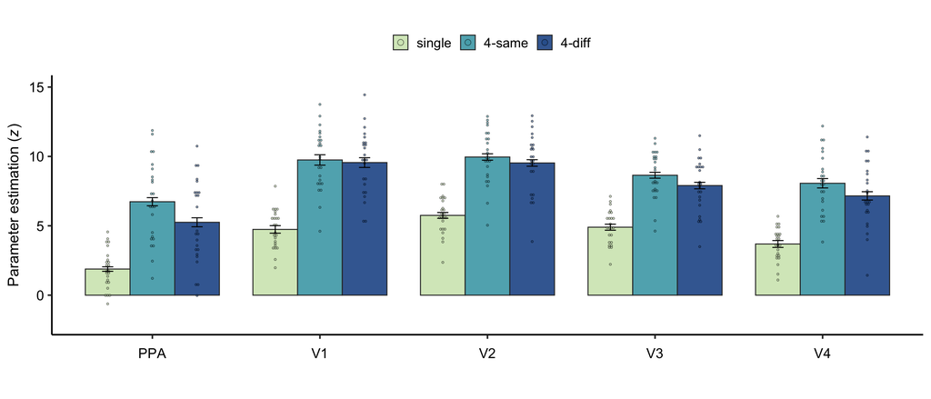

```r
targ_roi = c("PPA","v1","v2","v3","v4")
r1_hroi <- t34_allL.1 %>% filter(Roi %in% targ_roi)
# Roi != "v1", Roi != "v2", Roi != "v3", Roi != "v4")
r1_hroi_w <- t34_allW.1 %>% filter(Roi %in% targ_roi)
r1_hroi_g <- t34_allG.1 %>% filter(Roi %in% targ_roi)
r1_hroi_g$z <- r1_hroi_g$z.m
r1_main_allroi <- ggplot(data=r1_hroi, aes(x=Roi, y=z, fill=rgCon)) +
  # geom_hline(yintercept=0, linetype='solid', color='black', alpha =1, size=0.2) +
  stat_summary(fun = mean, geom = "bar", position="dodge", na.rm = TRUE,
               alpha = .9, width = 0.8,  size = 0.5, color = "gray20") +
  geom_dotplot(data=r1_hroi, aes(x=Roi, y=z, fill=rgCon),
               binaxis = "y", stackdir = "center", stackratio = 1,
               color = "black", alpha = 0.5, #position = "nudge",
               position=position_dodge(0.8),
               inherit.aes = TRUE, binwidth = 0.15) +
  # geom_jitter(aes(x=Roi, y=z, fill=rgCon, color = rgCon),
  #             position=position_dodge(0.1), cex=2
  #             ) +

  # facet_grid(.~Btw, scales="free_x", space = "free",
  #            labeller = labeller(Btw = c("1" = "Experimental Group","2" = "Control Group"))) +
  # geom_point(data=r1_hroi, aes(x=Roi, y=z, fill=rgCon), position = position_dodge(width=0.8),
             # size=2, show.legend=F, color="gray90") +
  # geom_segment(data=filter(r1_hroi_w, Roi == "ffa"), inherit.aes = FALSE,
  #              aes(x=0.73, y=filter(r1_hroi_w, Roi == "ffa")$single,
  #                  xend=1.0, yend=filter(r1_hroi_w, Roi == "ffa")$same),
  #              color="gray90", alpha = .7) +
  # geom_segment(data=filter(r1_hroi_w, Roi == "ffa"), inherit.aes = FALSE,
  #              aes(x=1, y=filter(r1_hroi_w, Roi == "ffa")$same,
  #                  xend=1.27, yend=filter(r1_hroi_w, Roi == "ffa")$diff),
  #              color="gray90", alpha = .7) +
  # geom_segment(data=filter(r1_hroi_w, Roi == "ppa"), inherit.aes = FALSE,
  #              aes(x=1.73, y=filter(r1_hroi_w, Roi == "ppa")$single,
  #                  xend=2.0, yend=filter(r1_hroi_w, Roi == "ppa")$same),
  #              color="gray90", alpha = .7) +
  # geom_segment(data=filter(r1_hroi_w, Roi == "ppa"), inherit.aes = FALSE,
  #              aes(x=2, y=filter(r1_hroi_w, Roi == "ppa")$same,
  #                  xend=2.27, yend=filter(r1_hroi_w, Roi == "ppa")$diff),
  #              color="gray90", alpha = .7) +
  # geom_pointrange(data=r1_hroi_g, aes(x = Roi, y=z.m, ymin = lower.ci, ymax = upper.ci),
                  # position = position_dodge(0.80), color = "darkred", size = 1, show.legend = FALSE) +
  geom_errorbar(data=r1_hroi_g, aes(ymin=lower.se, ymax=upper.se), width=.2,
                position=position_dodge(.8), color = "black") +
  scale_x_discrete(labels=c("PPA","V1","V2","V3","V4")) +
  scale_fill_manual(values = c("#D2E6BD", "#4AA7B4", "#235796"),  # , "#235796"
                    labels = c("single", "4-same", "4-diff")) +
  coord_cartesian(ylim = c(-2, 15), clip = "on") +
  labs(x = "", y = expression(paste("Parameter estimation (", italic("z"), ")"))) +
  theme_bw(base_size = 18) +
  theme(axis.title = element_text(face = "bold", size = 16, color = "black"),
        axis.text = element_text(face = "plain", hjust = 0.5, size = 15, color = "black"),
        axis.line=element_line(),
        axis.text.x = element_text(face = "plain", vjust = -1, size = 15, color = "black"),
        strip.text.x = element_text(face = "plain", size = 15, color = "black"),
        strip.background = element_blank(),
        panel.grid.major = element_blank(),
        panel.grid.minor = element_blank(),
        panel.border = element_blank(),
        panel.spacing=unit(1, "lines"),
        plot.margin = margin(1, 0.3, 1, 0.3, "cm"),
        legend.title = element_blank(),
        legend.position="top")
r1_main_allroi
```

```r
# ggsave("fBGRED_main12_verSM.jpg", plot = r1_main_allroi, width=8, height=6, unit='in', dpi=600)
```

```r
targ_roi = c("PPA", "v1", "v2", "v3", "v4")
t34_allL.1.vroi <- t34_allL.1 %>% filter(Roi %in% targ_roi)
t34.aov1 <- aov_ez(id="subj", dv="z", data = t34_allL.1.vroi, within = c("Roi", "rgCon"),
                   anova_table = list(correction = "none"))
nice(t34.aov1, es="pes") %>% kable(digits=3)
```

| Effect | df | MSE | F | pes | p.value |
| --- | --- | --- | --- | --- | --- |
| Roi | 4, 92 | 3.94 | 41.69 *** | .644 | <.001 |
| rgCon | 2, 46 | 2.50 | 271.35 *** | .922 | <.001 |
| Roi:rgCon | 8, 184 | 0.43 | 9.05 *** | .282 | <.001 |

각 관심 영역에서 자극 제시 조건에 따른 차이를 사후 검정하였다.

```r
p_h1 <- t34_allL.1.vroi %>%
  group_by(Roi) %>%
  rstatix::pairwise_t_test(z ~ rgCon,
                           p.adjust.method="bonferroni",
                           paired=T, detailed=T) %>%
  dplyr::select(Roi, group1, group2, estimate, conf.low, conf.high, df, statistic, p.adj, p.adj.signif)

p_h2 <- t34_allL.1.vroi %>% group_by(Roi) %>%
  rstatix::cohens_d(z ~ rgCon, paired=T, ci = F) %>%
  dplyr::select(Roi, group1, group2, effsize, magnitude)

merge(p_h1, p_h2, by = c("Roi", "group1", "group2")) %>% filter(group1=="single") %>%  kable(digits=3)
```

| Roi | group1 | group2 | estimate | conf.low | conf.high | df | statistic | p.adj | p.adj.signif | effsize | magnitude |
| --- | --- | --- | --- | --- | --- | --- | --- | --- | --- | --- | --- |
| PPA | single | diff | -3.372 | -4.139 | -2.605 | 23 | -9.095 | 0 | **** | -1.856 | large |
| PPA | single | same | -4.853 | -5.557 | -4.150 | 23 | -14.278 | 0 | **** | -2.915 | large |
| v1 | single | diff | -4.818 | -5.376 | -4.261 | 23 | -17.885 | 0 | **** | -3.651 | large |
| v1 | single | same | -5.005 | -5.594 | -4.417 | 23 | -17.596 | 0 | **** | -3.592 | large |
| v2 | single | diff | -3.780 | -4.307 | -3.252 | 23 | -14.825 | 0 | **** | -3.026 | large |
| v2 | single | same | -4.209 | -4.654 | -3.764 | 23 | -19.562 | 0 | **** | -3.993 | large |
| v3 | single | diff | -3.002 | -3.524 | -2.479 | 23 | -11.883 | 0 | **** | -2.426 | large |
| v3 | single | same | -3.745 | -4.186 | -3.304 | 23 | -17.576 | 0 | **** | -3.588 | large |
| v4 | single | diff | -3.467 | -4.234 | -2.700 | 23 | -9.350 | 0 | **** | -1.909 | large |
| v4 | single | same | -4.377 | -5.067 | -3.687 | 23 | -13.122 | 0 | **** | -2.678 | large |

```r
merge(p_h1, p_h2, by = c("Roi", "group1", "group2")) %>% filter(group1=="same") %>% kable(digits=3)
```

| Roi | group1 | group2 | estimate | conf.low | conf.high | df | statistic | p.adj | p.adj.signif | effsize | magnitude |
| --- | --- | --- | --- | --- | --- | --- | --- | --- | --- | --- | --- |
| PPA | same | diff | 1.481 | 1.081 | 1.882 | 23 | 7.655 | 0.000 | **** | 1.562 | large |
| v1 | same | diff | 0.187 | -0.211 | 0.585 | 23 | 0.973 | 1.000 | ns | 0.199 | negligible |
| v2 | same | diff | 0.429 | 0.089 | 0.769 | 23 | 2.607 | 0.047 | * | 0.532 | moderate |
| v3 | same | diff | 0.743 | 0.352 | 1.135 | 23 | 3.926 | 0.002 | ** | 0.801 | large |
| v4 | same | diff | 0.910 | 0.479 | 1.342 | 23 | 4.364 | 0.001 | *** | 0.891 | large |

**V1 결과**

```r
t34_allL.1.tmp <- t34_allL.1 %>% filter(Roi=="v1")
t34.aov1 <- aov_ez(id="subj", dv="z", data = t34_allL.1.tmp, within = c("rgCon"),
                   anova_table = list(correction = "none"))
nice(t34.aov1, es="pes") %>% kable(digits=3)
```

| Effect | df | MSE | F | pes | p.value |
| --- | --- | --- | --- | --- | --- |
| rgCon | 2, 46 | 0.76 | 253.54 *** | .917 | <.001 |

```r
t34_allL.1.tmp %>% group_by(Roi) %>% rstatix::pairwise_t_test(z ~ rgCon,
                           p.adjust.method="bonferroni",
                           paired=T, detailed=T) %>%
  dplyr::select(Roi, group1, group2, estimate, conf.low, conf.high, df, statistic, p.adj, p.adj.signif) %>% kable(digits=3)
```

| Roi | group1 | group2 | estimate | conf.low | conf.high | df | statistic | p.adj | p.adj.signif |
| --- | --- | --- | --- | --- | --- | --- | --- | --- | --- |
| v1 | single | same | -5.005 | -5.594 | -4.417 | 23 | -17.596 | 0 | **** |
| v1 | single | diff | -4.818 | -5.376 | -4.261 | 23 | -17.885 | 0 | **** |
| v1 | same | diff | 0.187 | -0.211 | 0.585 | 23 | 0.973 | 1 | ns |

```r
t34_allL.1.tmp %>% group_by(Roi) %>%
  rstatix::cohens_d(z ~ rgCon, paired=T, ci = F) %>% kable(digits=2)
```

| .y. | group1 | group2 | effsize | Roi | n1 | n2 | magnitude |
| --- | --- | --- | --- | --- | --- | --- | --- |
| z | single | same | -3.59 | v1 | 24 | 24 | large |
| z | single | diff | -3.65 | v1 | 24 | 24 | large |
| z | same | diff | 0.20 | v1 | 24 | 24 | negligible |

**V2 결과**

```r
t34_allL.1.tmp <- t34_allL.1 %>% filter(Roi=="v2")
t34.aov1 <- aov_ez(id="subj", dv="z", data = t34_allL.1.tmp, within = c("rgCon"),
                   anova_table = list(correction = "none"))
nice(t34.aov1, es="pes") %>% kable(digits=3)
```

| Effect | df | MSE | F | pes | p.value |
| --- | --- | --- | --- | --- | --- |
| rgCon | 2, 46 | 0.55 | 232.59 *** | .910 | <.001 |

```r
t34_allL.1.tmp %>% group_by(Roi) %>% rstatix::pairwise_t_test(z ~ rgCon,
                           p.adjust.method="bonferroni",
                           paired=T, detailed=T) %>%
  dplyr::select(Roi, group1, group2, estimate, conf.low, conf.high, df, statistic, p.adj, p.adj.signif) %>% kable(digits=3)
```

| Roi | group1 | group2 | estimate | conf.low | conf.high | df | statistic | p.adj | p.adj.signif |
| --- | --- | --- | --- | --- | --- | --- | --- | --- | --- |
| v2 | single | same | -4.209 | -4.654 | -3.764 | 23 | -19.562 | 0.000 | **** |
| v2 | single | diff | -3.780 | -4.307 | -3.252 | 23 | -14.825 | 0.000 | **** |
| v2 | same | diff | 0.429 | 0.089 | 0.769 | 23 | 2.607 | 0.047 | * |

```r
t34_allL.1.tmp %>% group_by(Roi) %>%
  rstatix::cohens_d(z ~ rgCon, paired=T, ci = F) %>% kable(digits=2)
```

| .y. | group1 | group2 | effsize | Roi | n1 | n2 | magnitude |
| --- | --- | --- | --- | --- | --- | --- | --- |
| z | single | same | -3.99 | v2 | 24 | 24 | large |
| z | single | diff | -3.03 | v2 | 24 | 24 | large |
| z | same | diff | 0.53 | v2 | 24 | 24 | moderate |

**V3 결과**

```r
t34_allL.1.tmp <- t34_allL.1 %>% filter(Roi=="v3")
t34.aov1 <- aov_ez(id="subj", dv="z", data = t34_allL.1.tmp, within = c("rgCon"),
                   anova_table = list(correction = "none"))

nice(t34.aov1, es="pes") %>% kable(digits=3)
```

| Effect | df | MSE | F | pes | p.value |
| --- | --- | --- | --- | --- | --- |
| rgCon | 2, 46 | 0.58 | 162.61 *** | .876 | <.001 |

```r
t34_allL.1.tmp %>% group_by(Roi) %>% rstatix::pairwise_t_test(z ~ rgCon,
                           p.adjust.method="bonferroni",
                           paired=T, detailed=T) %>%
  dplyr::select(Roi, group1, group2, estimate, conf.low, conf.high, df, statistic, p.adj, p.adj.signif) %>% kable(digits=3)
```

| Roi | group1 | group2 | estimate | conf.low | conf.high | df | statistic | p.adj | p.adj.signif |
| --- | --- | --- | --- | --- | --- | --- | --- | --- | --- |
| v3 | single | same | -3.745 | -4.186 | -3.304 | 23 | -17.576 | 0.000 | **** |
| v3 | single | diff | -3.002 | -3.524 | -2.479 | 23 | -11.883 | 0.000 | **** |
| v3 | same | diff | 0.743 | 0.352 | 1.135 | 23 | 3.926 | 0.002 | ** |

```r
t34_allL.1.tmp %>% group_by(Roi) %>%
  rstatix::cohens_d(z ~ rgCon, paired=T, ci = F) %>% kable(digits=2)
```

| .y. | group1 | group2 | effsize | Roi | n1 | n2 | magnitude |
| --- | --- | --- | --- | --- | --- | --- | --- |
| z | single | same | -3.59 | v3 | 24 | 24 | large |
| z | single | diff | -2.43 | v3 | 24 | 24 | large |
| z | same | diff | 0.80 | v3 | 24 | 24 | large |

**V4 결과**

```r
t34_allL.1.tmp <- t34_allL.1 %>% filter(Roi=="v4")
t34.aov1 <- aov_ez(id="subj", dv="z", data = t34_allL.1.tmp, within = c("rgCon"),
                   anova_table = list(correction = "none"))
nice(t34.aov1, es="pes") %>% kable(digits=3)
```

| Effect | df | MSE | F | pes | p.value |
| --- | --- | --- | --- | --- | --- |
| rgCon | 2, 46 | 1.17 | 109.51 *** | .826 | <.001 |

```r
t34_allL.1.tmp %>% group_by(Roi) %>% rstatix::pairwise_t_test(z ~ rgCon,
                           p.adjust.method="bonferroni",
                           paired=T, detailed=T) %>%
  dplyr::select(Roi, group1, group2, estimate, conf.low, conf.high, df, statistic, p.adj, p.adj.signif) %>% kable(digits=3)
```

| Roi | group1 | group2 | estimate | conf.low | conf.high | df | statistic | p.adj | p.adj.signif |
| --- | --- | --- | --- | --- | --- | --- | --- | --- | --- |
| v4 | single | same | -4.377 | -5.067 | -3.687 | 23 | -13.122 | 0.000 | **** |
| v4 | single | diff | -3.467 | -4.234 | -2.700 | 23 | -9.350 | 0.000 | **** |
| v4 | same | diff | 0.910 | 0.479 | 1.342 | 23 | 4.364 | 0.001 | *** |

```r
t34_allL.1.tmp %>% group_by(Roi) %>%
  rstatix::cohens_d(z ~ rgCon, paired=T, ci = F) %>% kable(digits=2)
```

| .y. | group1 | group2 | effsize | Roi | n1 | n2 | magnitude |
| --- | --- | --- | --- | --- | --- | --- | --- |
| z | single | same | -2.68 | v4 | 24 | 24 | large |
| z | single | diff | -1.91 | v4 | 24 | 24 | large |
| z | same | diff | 0.89 | v4 | 24 | 24 | large |

## 2.2 Background Functional Connectivity - Phase 2 Replication

### 2.2.1 Behavioral Performance

Phase 2 Attention Phsae, 1-back task 수행의 전반적인 요약치와 t-test 결과를 아래에 표시하였다.

```r
p2 <- read.csv("data/bg_behav.csv", header = T)

p2_l <- p2
p2_l$subj = factor(p2_l$subj)
p2_l <- p2_l %>% filter(subj!=99)
p2_l$run = factor(p2_l$run)
p2_l$block = factor(p2_l$block)
p2_l$cond = factor(p2_l$cond, levels=c(1,2), labels=c("face","scene"))
# p2_l$catch = factor(p2_l$catch)
p2_l$rt = p2_l$rt*1000
p2_l$corr = 0
p2_l$corr[p2_l$catch==1 & p2_l$resp==1] =1
p2_l$type = 0
p2_l$type[p2_l$catch==1 & p2_l$resp==1] = 1 #hit
p2_l$type[p2_l$catch==1 & p2_l$resp==0] = 2 #miss
p2_l$type[p2_l$catch==0 & p2_l$resp==1] = 3 #fa
p2_l$type[p2_l$catch==0 & p2_l$resp==0] = 4 #cr
p2_l$type <- factor(p2_l$type, levels=c(1,2,3,4), labels=c("hit","miss","fa","cr"))

headTail(p2_l)
```

```
##       subj  run block  cond onset catch resp  rt corr type
## 1        1    1     1 scene     0     0    0   0    0   cr
## 2        1    1     1 scene   1.5     0    0   0    0   cr
## 3        1    1     1 scene     3     0    0   0    0   cr
## 4        1    1     1 scene   4.5     0    0   0    0   cr
## ...   <NA> <NA>  <NA>  <NA>   ...   ...  ... ...  ... <NA>
## 13821   25    4    12  face   309     0    0   0    0   cr
## 13822   25    4    12  face 310.5     0    0   0    0   cr
## 13823   25    4    12  face   312     0    0   0    0   cr
## 13824   25    4    12  face 313.5     0    0   0    0   cr
```

```r
glimpse(p2_l, width = 70)
```

```
## Rows: 13,824
## Columns: 10
## $ subj  <fct> 1, 1, 1, 1, 1, 1, 1, 1, 1, 1, 1, 1, 1, 1, 1, 1, 1, 1, …
## $ run   <fct> 1, 1, 1, 1, 1, 1, 1, 1, 1, 1, 1, 1, 1, 1, 1, 1, 1, 1, …
## $ block <fct> 1, 1, 1, 1, 1, 1, 1, 1, 1, 1, 1, 1, 2, 2, 2, 2, 2, 2, …
## $ cond  <fct> scene, scene, scene, scene, scene, scene, scene, scene…
## $ onset <dbl> 0.0, 1.5, 3.0, 4.5, 6.0, 7.5, 9.0, 10.5, 12.0, 13.5, 1…
## $ catch <int> 0, 0, 0, 0, 0, 0, 0, 1, 0, 0, 0, 1, 0, 0, 0, 0, 0, 0, …
## $ resp  <int> 0, 0, 0, 0, 0, 0, 0, 0, 0, 0, 0, 1, 0, 0, 0, 0, 0, 0, …
## $ rt    <dbl> 0.0000, 0.0000, 0.0000, 0.0000, 0.0000, 0.0000, 0.0000…
## $ corr  <dbl> 0, 0, 0, 0, 0, 0, 0, 0, 0, 0, 0, 1, 0, 0, 0, 0, 0, 0, …
## $ type  <fct> cr, cr, cr, cr, cr, cr, cr, miss, cr, cr, cr, hit, cr,…
```

```r
# length(unique(p2_l$subj))
# check number of trials for each condition/subj
# table(p2_l$subj)
# table(p2_l$cond,  p2_l$catch, p2_l$subj)
```

두 주의 조건을 구분하지 않은 전반적인 수행 요약치 d-prime은 다음과 같다.

```r
# subject-level, long format
dmy <- dummyVars(" ~ type", data = p2_l)
p2_2 <- data.frame(predict(dmy, newdata = p2_l))
p2_3 <- cbind(p2_l, p2_2)
p2_allL <- p2_3  %>% group_by(subj) %>%
  dplyr::summarise(hit=sum(`type.hit`),
                 miss=sum(`type.miss`),
                 fa=sum(`type.fa`),
                 cr=sum(`type.cr`),
                 targets=sum(`type.hit`)+sum(`type.miss`),
                 dists=sum(`type.fa`)+sum(`type.cr`),
                 hit.r=sum(`type.hit`)/(sum(`type.hit`)+sum(`type.miss`)),
                 miss.r=sum(`type.miss`)/(sum(`type.hit`)+sum(`type.miss`)),
                 fa.r=sum(`type.fa`)/(sum(`type.fa`)+sum(`type.cr`)),
                 cr.r=sum(`type.cr`)/(sum(`type.fa`)+sum(`type.cr`))) %>%
  ungroup()
# p2_allL %>% kable(digits=2)

# subject-level, long format, calculating dprime
# indices <- psycho::dprime(p2_allL$hit, p2_allL$fa, p2_allL$miss, p2_allL$cr,
                          # p2_allL$targets, p2_allL$dists)
indices <- psycho::dprime(p2_allL$hit.r, p2_allL$fa.r, p2_allL$miss.r, p2_allL$cr.r,
                          1, 1)
p2_allL2 <- cbind(p2_allL, indices)
# p2_allL2 %>% kable(digits=2)

# check outlier
p2_allL3 <- p2_allL2 %>%
  mutate(lbound = mean(dprime)-3*sd(dprime),
         ubound = mean(dprime)+3*sd(dprime)) %>%
  mutate(Outlier = (dprime < lbound)|(dprime > ubound)) %>% # set outlier
  ungroup()

# summary table: grand mean
p2_allG.mean <- p2_allL3 %>%
  summarise(dprime.m = mean(dprime), dprime.sd = sd(dprime)) %>%
  ungroup()
p2_allG.mean %>% kable(digits=2)
```

| dprime.m | dprime.sd |
| --- | --- |
| 0.8 | 0.2 |

d prime 값이 0과 유의하게 다른지 one-sample t-test를 수행하였다.

```r
p_h1 <- p2_allL3 %>%
  rstatix::t_test(dprime ~ 1, mu = 0, detailed= T, alternative = "two.sided") %>%
  dplyr::select(estimate, conf.low, conf.high, df, statistic, p)

p_h2 <- p2_allL3 %>%
  rstatix::cohens_d(dprime ~ 1, mu = 0, ci = F) %>%
  dplyr::select(effsize, magnitude)

merge(p_h1, p_h2) %>% kable(digits=3)
```

| estimate | conf.low | conf.high | df | statistic | p | effsize | magnitude |
| --- | --- | --- | --- | --- | --- | --- | --- |
| 0.797 | 0.711 | 0.884 | 23 | 19.094 | 0 | 3.898 | large |

주의 조건별 요약치는 다음과 같다.

```r
# subject-level, long format
dmy <- dummyVars(" ~ type", data = p2_l)
p2_2 <- data.frame(predict(dmy, newdata = p2_l))
p2_3 <- cbind(p2_l, p2_2)
p2_allL <- p2_3  %>% group_by(subj, cond) %>%
  dplyr::summarise(hit=sum(`type.hit`),
                 miss=sum(`type.miss`),
                 fa=sum(`type.fa`),
                 cr=sum(`type.cr`),
                 targets=sum(`type.hit`)+sum(`type.miss`),
                 dists=sum(`type.fa`)+sum(`type.cr`),
                 hit.r=sum(`type.hit`)/(sum(`type.hit`)+sum(`type.miss`)),
                 miss.r=sum(`type.miss`)/(sum(`type.hit`)+sum(`type.miss`)),
                 fa.r=sum(`type.fa`)/(sum(`type.fa`)+sum(`type.cr`)),
                 cr.r=sum(`type.cr`)/(sum(`type.fa`)+sum(`type.cr`))) %>%
  ungroup()
## `summarise()` has grouped output by 'subj'. You can override using the `.groups` argument.
# p2_allL %>% kable(digits=2)

# subject-level, long format, calculating dprime
indices <- psycho::dprime(p2_allL$hit, p2_allL$fa, p2_allL$miss, p2_allL$cr,
                          p2_allL$targets, p2_allL$dists)
indices <- psycho::dprime(p2_allL$hit.r, p2_allL$fa.r, p2_allL$miss.r, p2_allL$cr.r,
                          1, 1)
p2_allL2 <- cbind(p2_allL, indices)
# p2_allL2 %>% kable(digits=2)

# check outlier
p2_allL3 <- p2_allL2 %>%
  mutate(lbound = mean(dprime)-3*sd(dprime),
         ubound = mean(dprime)+3*sd(dprime)) %>%
  mutate(Outlier = (dprime < lbound)|(dprime > ubound)) %>% # set outlier
  ungroup()
# p2_allL3 %>% dplyr::select(subj, cond, hit, miss, fa, cr, dprime) %>%kable(digits=2)
p2_allG <- p2_allL3 %>% group_by(cond) %>%
  summarise(dprime.m = mean(dprime), dprime.sd = sd(dprime)) %>%
  ungroup()

p2_allG$dprime.se <- Rmisc::summarySEwithin(data = p2_allL3, measurevar = "dprime", idvar = "subj",
                                      withinvars = c("cond"))$se
p2_allG$dprime.ci <- Rmisc::summarySEwithin(data = p2_allL3, measurevar = "dprime", idvar = "subj",
                                            withinvars = c("cond"))$ci
p2_allG <- p2_allG %>%
  mutate(lower.ci = dprime.m-dprime.ci,
         upper.ci = dprime.m+dprime.ci)
p2_allG %>% dplyr::select(cond, dprime.m, dprime.sd, dprime.se, lower.ci, upper.ci) %>% kable(digits=2)
```

| cond | dprime.m | dprime.sd | dprime.se | lower.ci | upper.ci |
| --- | --- | --- | --- | --- | --- |
| face | 0.83 | 0.24 | 0.03 | 0.76 | 0.90 |
| scene | 0.77 | 0.23 | 0.03 | 0.70 | 0.84 |

Face 조건과 Scene 조건 간의 paired t-test 결과, 두 조건 간의 수행 차이는 유의하지 않았다.

```r
p_h1 <- p2_allL3 %>%
  rstatix::pairwise_t_test(dprime ~ cond,
                           p.adjust.method="bonferroni",
                           paired=T, detailed=T) %>%
  dplyr::select(group1, group2, estimate, conf.low, conf.high, df, statistic, p.adj, p.adj.signif)

p_h2 <- p2_allL3 %>%
  rstatix::cohens_d(dprime ~ cond, paired=T, ci = F) %>%
  dplyr::select(group1, group2, effsize, magnitude)

merge(p_h1, p_h2, by = c("group1", "group2")) %>% kable(digits=3)
```

| group1 | group2 | estimate | conf.low | conf.high | df | statistic | p.adj | p.adj.signif | effsize | magnitude |
| --- | --- | --- | --- | --- | --- | --- | --- | --- | --- | --- |
| face | scene | 0.064 | -0.036 | 0.164 | 23 | 1.322 | 0.199 | ns | 0.27 | small |

### 2.2.2 fMRI results

**Al-aidroos et al., 2013. PNAS**의 결과를 재현하기 위해, Phase 2 Attention Phase에서 주의 조건에 따라 조절되는 상위 영역과 시각 영역 간의 Background Connectivity를 분석하였다.

```r
t2 <- read.csv("data/p2_BG_main2_nsm.csv", header = T)

t2_l <- gather(t2, bgCon, fc, rFFA:PPA, factor_key=TRUE)

# change class of main factors: double to factor
t2_l$subj = factor(t2_l$subj, levels=c("rd_01","rd_02","rd_03","rd_04","rd_05",
                                       "rd_06","rd_07","rd_08","rd_09","rd_10",
                                       "rd_11","rd_12","rd_13","rd_14","rd_15",
                                       "rd_16", "rd_18", "rd_19", "rd_20",
                                       "rd_21", "rd_22", "rd_23", "rd_24", "rd_25"),
                   labels=c(1,2,3,4,5,6,7,8,9,10,11,12,13,14,15,16,18,19,20,21,22,23,24,25))

t2_l <- t2_l %>% filter(subj!=99)

t2_l$vRoi = factor(t2_l$vROIs)
t2_l$bgCon = factor(t2_l$bgCon,
                    levels=c("rFFA","lFFA","FFA","rPPA","lPPA","PPA"),
                   labels=c("rFFA","lFFA","FFA","rPPA","lPPA","PPA"))
targ_bg = c("rFFA","rPPA")
targ_bg = c("FFA","PPA")
t2_l <- t2_l %>% filter(bgCon %in% targ_bg)
t2_l$hRoi <- t2_l$bgCon
t2_l$fRun <- t2_l$fcCon
t2_l$fRun <- factor(t2_l$fRun,
                    levels=c("faceRun", "sceRun"),
                    labels=c("face", "scene"))

t2_l <- t2_l %>% dplyr::select(subj,vRoi,fRun,hRoi,fc)

glimpse(t2_l, width = 70)
```

```
## Rows: 384
## Columns: 5
## $ subj <fct> 1, 1, 1, 1, 1, 1, 1, 1, 2, 2, 2, 2, 2, 2, 2, 2, 3, 3, 3…
## $ vRoi <fct> v1, v2, v3, v4, v1, v2, v3, v4, v1, v2, v3, v4, v1, v2,…
## $ fRun <fct> face, face, face, face, scene, scene, scene, scene, fac…
## $ hRoi <fct> FFA, FFA, FFA, FFA, FFA, FFA, FFA, FFA, FFA, FFA, FFA, …
## $ fc   <dbl> 0.037988160, 0.008802742, 0.073941240, 0.173024800, -0.…
```

요약치는 아래와 같다.

```r
# subject-level, long format
t2_allL <- t2_l %>% group_by(subj, vRoi, fRun, hRoi) %>%
  dplyr::summarise(fc=mean(fc)) %>%
  ungroup()
## `summarise()` has grouped output by 'subj', 'vRoi', 'fRun'. You can override using the `.groups` argument.

# subject-level, wide format
t2_allW <- t2_allL %>% group_by(subj, vRoi) %>% spread(key=fRun, value = fc)
t2_allW1 <- t2_allL %>% group_by(subj, vRoi) %>% spread(key=hRoi, value = fc)

# summary table: grand mean
t2_allG <- t2_allL %>% group_by(vRoi, fRun, hRoi) %>%
  summarise(fc.m = mean(fc), fc.sd = sd(fc)) %>%
  ungroup()
## `summarise()` has grouped output by 'vRoi', 'fRun'. You can override using the `.groups` argument.
t2_allG$fc.se <- Rmisc::summarySEwithin(data = t2_allL, measurevar = "fc",
                                        idvar = "subj", withinvars = c("vRoi", "fRun", "hRoi"))$se
t2_allG$fc.ci <- Rmisc::summarySEwithin(data = t2_allL, measurevar = "fc",
                                        idvar = "subj", withinvars = c("vRoi", "fRun", "hRoi"))$ci
t2_allG <- t2_allG %>%
  mutate(lower.ci = fc.m-fc.ci,
         upper.ci = fc.m+fc.ci,
         lower.se = fc.m-fc.se,
         upper.se = fc.m+fc.se)
# for between-subject design. check help(summarySE)
t2_allG <- t2_allG %>% dplyr::select(vRoi, hRoi, fRun, fc.m, fc.sd, fc.se, lower.ci, upper.ci, lower.se, upper.se)
t2_allG %>% dplyr::select(fRun, hRoi, vRoi, fc.m) %>%
  spread(key=vRoi, value=fc.m) %>% kable(digits=2)
```

| fRun | hRoi | v1 | v2 | v3 | v4 |
| --- | --- | --- | --- | --- | --- |
| face | FFA | 0.05 | 0.13 | 0.29 | 0.44 |
| face | PPA | -0.02 | 0.00 | 0.08 | 0.25 |
| scene | FFA | 0.01 | 0.08 | 0.23 | 0.38 |
| scene | PPA | 0.07 | 0.12 | 0.30 | 0.51 |

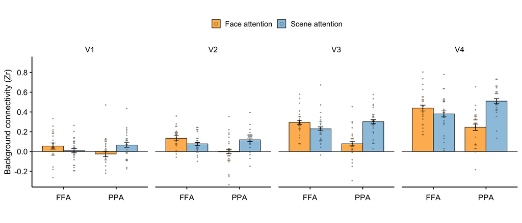

```r
t2_allG$fc <- t2_allG$fc.m

r2_bgfc.1 <- ggplot(data=t2_allL, aes(x=hRoi, y=fc, fill=fRun)) +
  geom_hline(yintercept=0, linetype='solid', color='black', alpha =1, size=0.4) +
  stat_summary(fun = mean, geom = "bar", position="dodge", na.rm = TRUE,
               alpha = .9, width = 0.8,  size = 0.4, color = "black") +
  facet_grid(.~vRoi, scales="free_x", space = "free",
             labeller = labeller(vRoi = c("v1" = "V1","v2" = "V2","v3" = "V3","v4" = "V4"))) +
  geom_dotplot(data=t2_allL, aes(x=hRoi, y=fc, fill=fRun),
               binaxis = "y", stackdir = "center", stackratio = 1,
               color = "black", alpha = 0.5, #position = "nudge",
               position=position_dodge(0.8),
               inherit.aes = TRUE, binwidth = 0.01) +
  # geom_point(data=t2_allL, aes(x=hRoi, y=fc, fill=fRun), position = position_dodge(width=0.8),
  #            size=2, show.legend=F, color="gray90") +
  # geom_segment(data=filter(t2_allW, hRoi == "ffa"), inherit.aes = FALSE,
  #              aes(x=0.8, y=filter(t2_allW, hRoi == "ffa")$face,
  #                  xend=1.2, yend=filter(t2_allW, hRoi == "ffa")$scene),
  #              color="gray90", alpha = .7) +
  # geom_segment(data=filter(t2_allW, hRoi == "ppa"), inherit.aes = FALSE,
  #              aes(x=1.8, y=filter(t2_allW, hRoi == "ppa")$face,
  #                  xend=2.2, yend=filter(t2_allW, hRoi == "ppa")$scene),
  #              color="gray90", alpha = .7) +
  # geom_pointrange(data=t2_allG, aes(x = hRoi, y=fc.m, ymin = lower.ci, ymax = upper.ci),
                  # position = position_dodge(0.80), color = "darkred", size = 1, show.legend = FALSE) +
  geom_errorbar(data=t2_allG, aes(ymin=lower.se, ymax=upper.se), width=.2,
                position=position_dodge(.8), color = "black") +
  scale_x_discrete(labels=c("FFA","PPA")) +

  scale_fill_manual(values = c("#feb24c", "#91bfdb"), # c("#feb24c", "#91bfdb"),
                    labels = c("Face attention", "Scene attention")) +
  coord_cartesian(ylim = c(-0.3, 0.9), clip = "on") +
  scale_y_continuous(breaks=c(-0.2, 0, 0.2, 0.4, 0.6, 0.8)) +
  labs(x = "", y = "Background connectivity (Zr)") +
  theme_bw(base_size = 18) +
  theme(axis.title = element_text(face = "plain", size = 16, color = "black"),
        axis.text = element_text(face = "plain", hjust = 0.5, size = 15, color = "black"),
        axis.line=element_line(),
        axis.title.y = element_text(face = "plain", size = 16, color = "black"),
        axis.title.x = element_text(face = "plain", size = 16, vjust = -2.5, color = "black"),
        axis.text.x = element_text(face = "plain", vjust = -1, size = 15, color = "black"),
        strip.text.x = element_text(face = "plain", size = 15, color = "black"),
        strip.background = element_blank(),
        panel.grid.major = element_blank(),
        panel.grid.minor = element_blank(),
        panel.border = element_blank(),
        panel.spacing=unit(1, "lines"),
        plot.margin = margin(1, 0.3, 1, 0.3, "cm"),
        legend.title = element_blank(),
        legend.position="top")
r2_bgfc.1
```

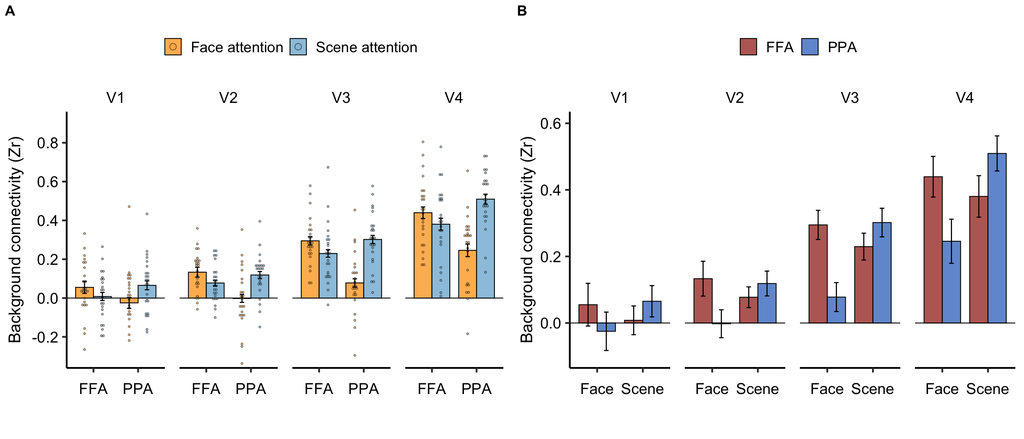

```r
# ggsave("fBGRED_bgfc1_verSM.jpg", plot = r2_bgfc.1, width=8, height=6, unit='in', dpi=600)

r2_bgfc.2 <- ggplot(data=t2_allL, aes(x=fRun, y=fc, fill=hRoi)) +
  geom_hline(yintercept=0, linetype='solid', color='black', alpha =1, size=0.4) +
  stat_summary(fun = mean, geom = "bar", position="dodge", na.rm = TRUE,
               alpha = .9, width = 0.8,  size = 0.4, color = "black") +
  # geom_point(data=t2_allL, aes(x=fRun, y=fc, fill=hRoi), position = position_dodge(width=0.8),
  #            size=2, show.legend=F, color="gray90") +
  # geom_segment(data=filter(t2_allW1,fRun == "face"), inherit.aes = FALSE,
  #              aes(x=0.8, y=filter(t2_allW1, fRun == "face")$ffa,
  #                  xend=1.2, yend=filter(t2_allW1, fRun == "face")$ppa),
  #              color="gray90", alpha = .7) +
  # geom_segment(data=filter(t2_allW1,fRun == "scene"), inherit.aes = FALSE,
  #              aes(x=1.8, y=filter(t2_allW1, fRun == "scene")$ffa,
  #                  xend=2.2, yend=filter(t2_allW1, fRun == "scene")$ppa),
  #              color="gray90", alpha = .7) +
  # geom_pointrange(data=t2_allG, aes(x = fRun, y=fc.m, ymin = lower.ci, ymax = upper.ci),
  #                 position = position_dodge(0.80), color = "darkred", size = 1, show.legend = FALSE) +
  geom_errorbar(data=t2_allG, aes(ymin=lower.ci, ymax=upper.ci), width=.2,
                position=position_dodge(.8), color = "black") +
  facet_grid(.~vRoi, scales="free_x", space = "free",
             labeller = labeller(vRoi = c("v1" = "V1","v2" = "V2","v3" = "V3","v4" = "V4"))) +
  scale_x_discrete(labels=c("Face","Scene")) +
  # scale_x_discrete(labels=c("Face\nattention","Scene\nattention")) +
  scale_fill_manual(values = c("#B35750", "#628DCF"), # c("#feb24c", "#91bfdb"),
                    labels = c("FFA", "PPA")) +
  coord_cartesian(ylim = c(-0.1, 0.6), clip = "on") +
  labs(x = " ", y = "Background connectivity (Zr)") +
  theme_bw(base_size = 18) +
  theme(axis.title = element_text(face = "plain", size = 16, color = "black"),
        axis.text = element_text(face = "plain", hjust = 0.5, size = 15, color = "black"),
        axis.line=element_line(),
        axis.title.y = element_text(face = "plain", size = 16, color = "black"),
        axis.title.x = element_text(face = "plain", size = 16, vjust = -2.5, color = "black"),
        axis.text.x = element_text(face = "plain", vjust = -1, size = 15, color = "black"),
        strip.text.x = element_text(face = "plain", size = 15, color = "black"),
        strip.background = element_blank(),
        panel.grid.major = element_blank(),
        panel.grid.minor = element_blank(),
        panel.border = element_blank(),
        panel.spacing=unit(1, "lines"),
        plot.margin = margin(1, 0.3, 1, 0.3, "cm"),
        legend.title = element_blank(),
        legend.position="top")
# r2_bgfc.2
# ggsave("fBGRED_bgfc2_verSM.jpg", plot = r2_bgfc.2, width=8, height=6, unit='in', dpi=600)

ggarrange(r2_bgfc.1, r2_bgfc.2, ncol=2,
          labels=c("A","B"))
```

```r
t2.aov1 <- aov_ez(id="subj", dv="fc", data = t2_allL, within = c("vRoi", "fRun", "hRoi"),
                  anova_table = list(correction = "none"))
nice(t2.aov1, es="pes") %>% kable(digits=3)
```

| Effect | df | MSE | F | pes | p.value |
| --- | --- | --- | --- | --- | --- |
| vRoi | 3, 69 | 0.03 | 91.56 *** | .799 | <.001 |
| fRun | 1, 23 | 0.01 | 22.31 *** | .492 | <.001 |
| hRoi | 1, 23 | 0.05 | 3.28 + | .125 | .083 |
| vRoi:fRun | 3, 69 | 0.00 | 9.71 *** | .297 | <.001 |
| vRoi:hRoi | 3, 69 | 0.01 | 1.75 | .071 | .164 |
| fRun:hRoi | 1, 23 | 0.02 | 59.41 *** | .721 | <.001 |
| vRoi:fRun:hRoi | 3, 69 | 0.00 | 9.96 *** | .302 | <.001 |

사후 검정 결과는 아래와 같다.

```r
ph1 <- t2_allL %>%
  group_by(vRoi, hRoi) %>%
  rstatix::pairwise_t_test(fc ~ fRun,
                           p.adjust.method="bonferroni",
                           paired=T, detailed=T) %>%
  dplyr::select(vRoi, hRoi, group1, group2, estimate, conf.low, conf.high, df, statistic, p.adj, p.adj.signif)

ph2 <- t2_allL %>%
  group_by(vRoi, hRoi) %>%
  rstatix::cohens_d(fc ~ fRun, paired=T, ci = F) %>%
  dplyr::select(vRoi, hRoi, group1, group2, effsize, magnitude)

merge(ph1, ph2, by = c("vRoi", "hRoi", "group1", "group2")) %>% kable(digits=3)
```

| vRoi | hRoi | group1 | group2 | estimate | conf.low | conf.high | df | statistic | p.adj | p.adj.signif | effsize | magnitude |
| --- | --- | --- | --- | --- | --- | --- | --- | --- | --- | --- | --- | --- |
| v1 | FFA | face | scene | 0.047 | -0.003 | 0.097 | 23 | 1.936 | 0.065 | ns | 0.395 | small |
| v1 | PPA | face | scene | -0.090 | -0.162 | -0.019 | 23 | -2.605 | 0.016 | * | -0.532 | moderate |
| v2 | FFA | face | scene | 0.056 | 0.007 | 0.105 | 23 | 2.363 | 0.027 | * | 0.482 | small |
| v2 | PPA | face | scene | -0.121 | -0.169 | -0.073 | 23 | -5.185 | 0.000 | **** | -1.058 | large |
| v3 | FFA | face | scene | 0.065 | 0.021 | 0.109 | 23 | 3.074 | 0.005 | ** | 0.627 | moderate |
| v3 | PPA | face | scene | -0.224 | -0.268 | -0.180 | 23 | -10.573 | 0.000 | **** | -2.158 | large |
| v4 | FFA | face | scene | 0.059 | 0.009 | 0.109 | 23 | 2.444 | 0.023 | * | 0.499 | small |
| v4 | PPA | face | scene | -0.264 | -0.321 | -0.207 | 23 | -9.526 | 0.000 | **** | -1.944 | large |

```r
ph1 <- t2_allL %>%
  group_by(vRoi, fRun) %>%
  rstatix::pairwise_t_test(fc ~ hRoi,
                           p.adjust.method="bonferroni",
                           paired=T, detailed=T) %>%
  dplyr::select(vRoi, fRun, group1, group2, estimate, conf.low, conf.high, df, statistic, p.adj, p.adj.signif)

ph2 <- t2_allL %>%
  group_by(vRoi, fRun) %>%
  rstatix::cohens_d(fc ~ hRoi, paired=T, ci = F) %>%
  dplyr::select(vRoi, fRun, group1, group2, effsize, magnitude)

merge(ph1, ph2, by = c("vRoi", "fRun", "group1", "group2")) %>% kable(digits=3)
```

| vRoi | fRun | group1 | group2 | estimate | conf.low | conf.high | df | statistic | p.adj | p.adj.signif | effsize | magnitude |
| --- | --- | --- | --- | --- | --- | --- | --- | --- | --- | --- | --- | --- |
| v1 | face | FFA | PPA | 0.080 | -0.018 | 0.178 | 23 | 1.681 | 0.106 | ns | 0.343 | small |
| v1 | scene | FFA | PPA | -0.057 | -0.104 | -0.010 | 23 | -2.530 | 0.019 | * | -0.517 | moderate |
| v2 | face | FFA | PPA | 0.135 | 0.061 | 0.210 | 23 | 3.741 | 0.001 | ** | 0.764 | moderate |
| v2 | scene | FFA | PPA | -0.041 | -0.079 | -0.004 | 23 | -2.264 | 0.033 | * | -0.462 | small |
| v3 | face | FFA | PPA | 0.217 | 0.149 | 0.285 | 23 | 6.641 | 0.000 | **** | 1.356 | large |
| v3 | scene | FFA | PPA | -0.072 | -0.127 | -0.018 | 23 | -2.747 | 0.012 | * | -0.561 | moderate |
| v4 | face | FFA | PPA | 0.194 | 0.094 | 0.294 | 23 | 4.022 | 0.001 | *** | 0.821 | large |
| v4 | scene | FFA | PPA | -0.129 | -0.187 | -0.071 | 23 | -4.602 | 0.000 | *** | -0.939 | large |

구형성 가정 위배에 따른 보정을 고려하여 시각 영역별 분석을 수행하였다.

**V1 결과**

```r
t2_allL.tmp <- t2_allL %>% filter(vRoi=="v1")

t2.aov1.1 <- aov_ez(id="subj", dv="fc", data = t2_allL.tmp, within = c("fRun", "hRoi"),
                    anova_table = list(correction = "none"))
nice(t2.aov1.1, es="pes") %>% kable(digits=3)
```

| Effect | df | MSE | F | pes | p.value |
| --- | --- | --- | --- | --- | --- |
| fRun | 1, 23 | 0.01 | 1.68 | .068 | .207 |
| hRoi | 1, 23 | 0.02 | 0.17 | .007 | .687 |
| fRun:hRoi | 1, 23 | 0.01 | 7.65 * | .250 | .011 |

```r
ph1 <- t2_allL.tmp %>%
  group_by(vRoi, hRoi) %>%
  rstatix::pairwise_t_test(fc ~ fRun,
                           p.adjust.method="bonferroni",
                           paired=T, detailed=T) %>%
  dplyr::select(vRoi, hRoi, group1, group2, estimate, conf.low, conf.high, df, statistic, p.adj, p.adj.signif)

ph2 <- t2_allL.tmp %>%
  group_by(vRoi, hRoi) %>%
  rstatix::cohens_d(fc ~ fRun, paired=T, ci = F) %>%
  dplyr::select(vRoi, hRoi, group1, group2, effsize, magnitude)

merge(ph1, ph2, by = c("vRoi", "hRoi", "group1", "group2")) %>% kable(digits=3)
```

| vRoi | hRoi | group1 | group2 | estimate | conf.low | conf.high | df | statistic | p.adj | p.adj.signif | effsize | magnitude |
| --- | --- | --- | --- | --- | --- | --- | --- | --- | --- | --- | --- | --- |
| v1 | FFA | face | scene | 0.047 | -0.003 | 0.097 | 23 | 1.936 | 0.065 | ns | 0.395 | small |
| v1 | PPA | face | scene | -0.090 | -0.162 | -0.019 | 23 | -2.605 | 0.016 | * | -0.532 | moderate |

```r
ph1 <- t2_allL.tmp %>%
  group_by(vRoi, fRun) %>%
  rstatix::pairwise_t_test(fc ~ hRoi,
                           p.adjust.method="bonferroni",
                           paired=T, detailed=T) %>%
  dplyr::select(vRoi, fRun, group1, group2, estimate, conf.low, conf.high, df, statistic, p.adj, p.adj.signif)

ph2 <- t2_allL.tmp %>%
  group_by(vRoi, fRun) %>%
  rstatix::cohens_d(fc ~ hRoi, paired=T, ci = F) %>%
  dplyr::select(vRoi, fRun, group1, group2, effsize, magnitude)

merge(ph1, ph2, by = c("vRoi", "fRun", "group1", "group2")) %>% kable(digits=3)
```

| vRoi | fRun | group1 | group2 | estimate | conf.low | conf.high | df | statistic | p.adj | p.adj.signif | effsize | magnitude |
| --- | --- | --- | --- | --- | --- | --- | --- | --- | --- | --- | --- | --- |
| v1 | face | FFA | PPA | 0.080 | -0.018 | 0.178 | 23 | 1.681 | 0.106 | ns | 0.343 | small |
| v1 | scene | FFA | PPA | -0.057 | -0.104 | -0.010 | 23 | -2.530 | 0.019 | * | -0.517 | moderate |

**V2 결과**

```r
t2_allL.tmp <- t2_allL %>% filter(vRoi=="v2")

t2.aov1.1 <- aov_ez(id="subj", dv="fc", data = t2_allL.tmp, within = c("fRun", "hRoi"),
                    anova_table = list(correction = "none"))
nice(t2.aov1.1, es="pes") %>% kable(digits=3)
```

| Effect | df | MSE | F | pes | p.value |
| --- | --- | --- | --- | --- | --- |
| fRun | 1, 23 | 0.01 | 3.85 + | .143 | .062 |
| hRoi | 1, 23 | 0.01 | 4.06 + | .150 | .056 |
| fRun:hRoi | 1, 23 | 0.01 | 28.40 *** | .553 | <.001 |

```r
ph1 <- t2_allL.tmp %>%
  group_by(vRoi, hRoi) %>%
  rstatix::pairwise_t_test(fc ~ fRun,
                           p.adjust.method="bonferroni",
                           paired=T, detailed=T) %>%
  dplyr::select(vRoi, hRoi, group1, group2, estimate, conf.low, conf.high, df, statistic, p.adj, p.adj.signif)

ph2 <- t2_allL.tmp %>%
  group_by(vRoi, hRoi) %>%
  rstatix::cohens_d(fc ~ fRun, paired=T, ci = F) %>%
  dplyr::select(vRoi, hRoi, group1, group2, effsize, magnitude)

merge(ph1, ph2, by = c("vRoi", "hRoi", "group1", "group2")) %>% kable(digits=3)
```

| vRoi | hRoi | group1 | group2 | estimate | conf.low | conf.high | df | statistic | p.adj | p.adj.signif | effsize | magnitude |
| --- | --- | --- | --- | --- | --- | --- | --- | --- | --- | --- | --- | --- |
| v2 | FFA | face | scene | 0.056 | 0.007 | 0.105 | 23 | 2.363 | 0.027 | * | 0.482 | small |
| v2 | PPA | face | scene | -0.121 | -0.169 | -0.073 | 23 | -5.185 | 0.000 | **** | -1.058 | large |

```r
ph1 <- t2_allL.tmp %>%
  group_by(vRoi, fRun) %>%
  rstatix::pairwise_t_test(fc ~ hRoi,
                           p.adjust.method="bonferroni",
                           paired=T, detailed=T) %>%
  dplyr::select(vRoi, fRun, group1, group2, estimate, conf.low, conf.high, df, statistic, p.adj, p.adj.signif)

ph2 <- t2_allL.tmp %>%
  group_by(vRoi, fRun) %>%
  rstatix::cohens_d(fc ~ hRoi, paired=T, ci = F) %>%
  dplyr::select(vRoi, fRun, group1, group2, effsize, magnitude)

merge(ph1, ph2, by = c("vRoi", "fRun", "group1", "group2")) %>% kable(digits=3)
```

| vRoi | fRun | group1 | group2 | estimate | conf.low | conf.high | df | statistic | p.adj | p.adj.signif | effsize | magnitude |
| --- | --- | --- | --- | --- | --- | --- | --- | --- | --- | --- | --- | --- |
| v2 | face | FFA | PPA | 0.135 | 0.061 | 0.210 | 23 | 3.741 | 0.001 | ** | 0.764 | moderate |
| v2 | scene | FFA | PPA | -0.041 | -0.079 | -0.004 | 23 | -2.264 | 0.033 | * | -0.462 | small |

**V3 결과**

```r
t2_allL.tmp <- t2_allL %>% filter(vRoi=="v3")

t2.aov1.1 <- aov_ez(id="subj", dv="fc", data = t2_allL.tmp, within = c("fRun", "hRoi"),
                    anova_table = list(correction = "none"))
nice(t2.aov1.1, es="pes") %>% kable(digits=3)
```

| Effect | df | MSE | F | pes | p.value |
| --- | --- | --- | --- | --- | --- |
| fRun | 1, 23 | 0.01 | 25.32 *** | .524 | <.001 |
| hRoi | 1, 23 | 0.02 | 7.69 * | .251 | .011 |
| fRun:hRoi | 1, 23 | 0.00 | 103.97 *** | .819 | <.001 |

```r
ph1 <- t2_allL.tmp %>%
  group_by(vRoi, hRoi) %>%
  rstatix::pairwise_t_test(fc ~ fRun,
                           p.adjust.method="bonferroni",
                           paired=T, detailed=T) %>%
  dplyr::select(vRoi, hRoi, group1, group2, estimate, conf.low, conf.high, df, statistic, p.adj, p.adj.signif)

ph2 <- t2_allL.tmp %>%
  group_by(vRoi, hRoi) %>%
  rstatix::cohens_d(fc ~ fRun, paired=T, ci = F) %>%
  dplyr::select(vRoi, hRoi, group1, group2, effsize, magnitude)

merge(ph1, ph2, by = c("vRoi", "hRoi", "group1", "group2")) %>% kable(digits=3)
```

| vRoi | hRoi | group1 | group2 | estimate | conf.low | conf.high | df | statistic | p.adj | p.adj.signif | effsize | magnitude |
| --- | --- | --- | --- | --- | --- | --- | --- | --- | --- | --- | --- | --- |
| v3 | FFA | face | scene | 0.065 | 0.021 | 0.109 | 23 | 3.074 | 0.005 | ** | 0.627 | moderate |
| v3 | PPA | face | scene | -0.224 | -0.268 | -0.180 | 23 | -10.573 | 0.000 | **** | -2.158 | large |

```r
ph1 <- t2_allL.tmp %>%
  group_by(vRoi, fRun) %>%
  rstatix::pairwise_t_test(fc ~ hRoi,
                           p.adjust.method="bonferroni",
                           paired=T, detailed=T) %>%
  dplyr::select(vRoi, fRun, group1, group2, estimate, conf.low, conf.high, df, statistic, p.adj, p.adj.signif)

ph2 <- t2_allL.tmp %>%
  group_by(vRoi, fRun) %>%
  rstatix::cohens_d(fc ~ hRoi, paired=T, ci = F) %>%
  dplyr::select(vRoi, fRun, group1, group2, effsize, magnitude)

merge(ph1, ph2, by = c("vRoi", "fRun", "group1", "group2")) %>% kable(digits=3)
```

| vRoi | fRun | group1 | group2 | estimate | conf.low | conf.high | df | statistic | p.adj | p.adj.signif | effsize | magnitude |
| --- | --- | --- | --- | --- | --- | --- | --- | --- | --- | --- | --- | --- |
| v3 | face | FFA | PPA | 0.217 | 0.149 | 0.285 | 23 | 6.641 | 0.000 | **** | 1.356 | large |
| v3 | scene | FFA | PPA | -0.072 | -0.127 | -0.018 | 23 | -2.747 | 0.012 | * | -0.561 | moderate |

**V4 결과**

```r
t2_allL.tmp <- t2_allL %>% filter(vRoi=="v4")

t2.aov1.1 <- aov_ez(id="subj", dv="fc", data = t2_allL.tmp, within = c("fRun", "hRoi"),
                    anova_table = list(correction = "none"))
nice(t2.aov1.1, es="pes") %>% kable(digits=3)
```

| Effect | df | MSE | F | pes | p.value |
| --- | --- | --- | --- | --- | --- |
| fRun | 1, 23 | 0.01 | 38.47 *** | .626 | <.001 |
| hRoi | 1, 23 | 0.03 | 0.91 | .038 | .350 |
| fRun:hRoi | 1, 23 | 0.01 | 64.53 *** | .737 | <.001 |

```r
ph1 <- t2_allL.tmp %>%
  group_by(vRoi, hRoi) %>%
  rstatix::pairwise_t_test(fc ~ fRun,
                           p.adjust.method="bonferroni",
                           paired=T, detailed=T) %>%
  dplyr::select(vRoi, hRoi, group1, group2, estimate, conf.low, conf.high, df, statistic, p.adj, p.adj.signif)

ph2 <- t2_allL.tmp %>%
  group_by(vRoi, hRoi) %>%
  rstatix::cohens_d(fc ~ fRun, paired=T, ci = F) %>%
  dplyr::select(vRoi, hRoi, group1, group2, effsize, magnitude)

merge(ph1, ph2, by = c("vRoi", "hRoi", "group1", "group2")) %>% kable(digits=3)
```

| vRoi | hRoi | group1 | group2 | estimate | conf.low | conf.high | df | statistic | p.adj | p.adj.signif | effsize | magnitude |
| --- | --- | --- | --- | --- | --- | --- | --- | --- | --- | --- | --- | --- |
| v4 | FFA | face | scene | 0.059 | 0.009 | 0.109 | 23 | 2.444 | 0.023 | * | 0.499 | small |
| v4 | PPA | face | scene | -0.264 | -0.321 | -0.207 | 23 | -9.526 | 0.000 | **** | -1.944 | large |

```r
ph1 <- t2_allL.tmp %>%
  group_by(vRoi, fRun) %>%
  rstatix::pairwise_t_test(fc ~ hRoi,
                           p.adjust.method="bonferroni",
                           paired=T, detailed=T) %>%
  dplyr::select(vRoi, fRun, group1, group2, estimate, conf.low, conf.high, df, statistic, p.adj, p.adj.signif)

ph2 <- t2_allL.tmp %>%
  group_by(vRoi, fRun) %>%
  rstatix::cohens_d(fc ~ hRoi, paired=T, ci = F) %>%
  dplyr::select(vRoi, fRun, group1, group2, effsize, magnitude)

merge(ph1, ph2, by = c("vRoi", "fRun", "group1", "group2")) %>% kable(digits=3)
```

| vRoi | fRun | group1 | group2 | estimate | conf.low | conf.high | df | statistic | p.adj | p.adj.signif | effsize | magnitude |
| --- | --- | --- | --- | --- | --- | --- | --- | --- | --- | --- | --- | --- |
| v4 | face | FFA | PPA | 0.194 | 0.094 | 0.294 | 23 | 4.022 | 0.001 | *** | 0.821 | large |
| v4 | scene | FFA | PPA | -0.129 | -0.187 | -0.071 | 23 | -4.602 | 0.000 | *** | -0.939 | large |

## 2.3 Linking voxel-wise background functional connectivity to the redundancy gain effect (voxel-level)

### 2.3.1 각 복셀별 RG Difference Score와 bgFC 간의 상관 관계 (P2 bgFC)

관심 시각 영역 (V1~V4) 에서 Redundancy Gain Effect가 PPA-VC Voxel-wise Background Connectivity(bgFC)의 강도에 따라 조절되는지 검증하기 위해 상관 분석을 수행하였다. 각 참가자 내의 관심 영역에서 voxel 별로 4-Same - 4-Diff의 Difference Score를 계산한 후 각 voxel 별 PPA-VC bgFC 값과 상관을 계산하였다. 이 분석에서 0 보다 유의하게 상관계수가 높다는 것은 bgFC 강도가 높을수록 Redundacy Gain Effect의 강도도 높다는 것을 나타낸다.

```r
s1 <- read.csv("data/p12_RGandBG_corr_main3_nsm.csv", header = T)

s1_l <- s1
# change class of main factors: double to factor
s1_l$subj = factor(s1_l$subj, levels=c("rd_01","rd_02","rd_03","rd_04","rd_05",
                                       "rd_06","rd_07","rd_08","rd_09","rd_10",
                                       "rd_11","rd_12","rd_13","rd_14","rd_15",
                                       "rd_16", "rd_18", "rd_19", "rd_20",
                                       "rd_21", "rd_22", "rd_23", "rd_24", "rd_25"),
                   labels=c(1,2,3,4,5,6,7,8,9,10,11,12,13,14,15,16,18,19,20,21,22,23,24,25))

# s1_l <- s1_l %>% filter(subj!=4, subj!=5, subj!=6, subj!=8)

s1_l$vRoi = factor(s1_l$vRoi)
s1_l$hRoi = factor(s1_l$hRoi, levels = c("rPPA", "lPPA", "PPA"))
```

각 관심 영역에서 voxel 별 difference score와 bgFC의 pearson correlation coefficient를 Fisher의 Z transform하여 요약하였다.

```r
s1_allL <- s1_l %>%
  dplyr::select(subj, hRoi, vRoi, Zr) %>%
  group_by(subj, hRoi, vRoi) %>%
  dplyr::summarise(Zr=mean(Zr)) %>%
  ungroup()
## `summarise()` has grouped output by 'subj', 'hRoi'. You can override using the `.groups` argument.
# s1_allL %>% kable(digits=2)

# subject-level, wide format
s1_allW <- s1_allL %>% dplyr::select(subj, hRoi, vRoi, Zr) %>% spread(key=vRoi, value = Zr)
# s1_allW %>% kable(digits=2)

# summary table: grand mean
s1_allG <- s1_allL %>% group_by(hRoi, vRoi) %>%
  summarise(Zr.m = mean(Zr), Zr.sd = sd(Zr)) %>%
  ungroup()
## `summarise()` has grouped output by 'hRoi'. You can override using the `.groups` argument.
s1_allG$Zr.se <- Rmisc::summarySEwithin(data = s1_allL, measurevar = "Zr",
                                        idvar = "subj", withinvars = c("hRoi","vRoi"))$se
s1_allG$Zr.ci <- Rmisc::summarySEwithin(data = s1_allL, measurevar = "Zr",
                                        idvar = "subj", withinvars = c("hRoi","vRoi"))$ci
s1_allG <- s1_allG %>%
  mutate(lower.ci = Zr.m-Zr.ci,
         upper.ci = Zr.m+Zr.ci,
         lower.se = Zr.m-Zr.se,
         upper.se = Zr.m+Zr.se)
s1_allG %>% dplyr::select(hRoi, vRoi, Zr.m) %>%
  spread(key=vRoi, value = Zr.m) %>% kable(digits=2)
```

| hRoi | v1 | v2 | v3 | v4 |
| --- | --- | --- | --- | --- |
| rPPA | 0.00 | 0.03 | 0.14 | 0.13 |
| lPPA | 0.02 | 0.02 | 0.13 | 0.13 |
| PPA | 0.01 | 0.03 | 0.15 | 0.14 |

각 관심 영역에서 voxel 별 difference score와 bgFC의 Zr을 그래프로 나타내었다. 점은 평군, error bar는 95% CI를 나타낸다.

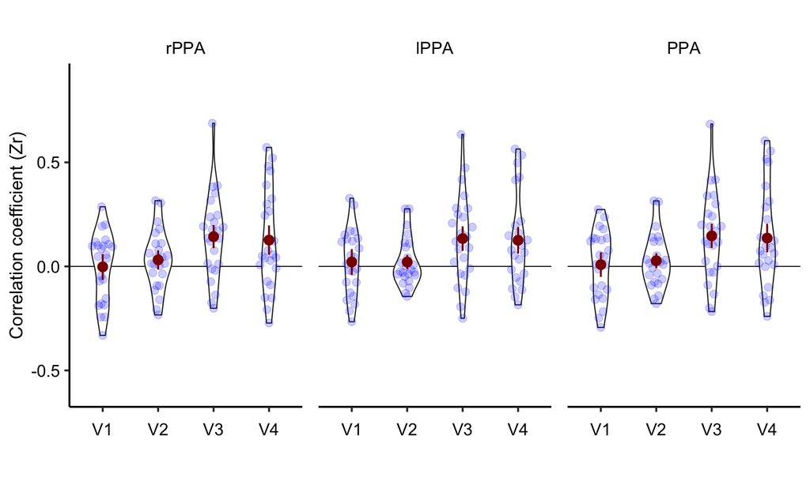

```r
s1_allL.tmp <- s1_allL
r5_RG_with_bgfc.1 <- ggplot(data=s1_allL.tmp, aes(x=vRoi, y=Zr)) + #, fill=vRoi
  geom_hline(yintercept=0, linetype='solid', color='black', alpha =1, size=0.4) +
  geom_violin(width = 0.5, trim=TRUE) +
  ggbeeswarm::geom_quasirandom(color = "blue", size = 3, alpha = 0.2, width = 0.2) +
  facet_grid(.~hRoi, scales="free_x", space = "free") +

  #stat_summary(fun = mean, geom = "bar", position="dodge", na.rm = TRUE, alpha = .9, width = 0.8,  size = 1.02, show.legend=F) +
  #geom_point(data=s1_allL, aes(x=vRoi, y=Zr, fill=vRoi), position = position_dodge(width=0.8),
  #           size=2, show.legend=F, color="gray90") +
  geom_pointrange(data=s1_allG, aes(x = vRoi, y=Zr.m, ymin = lower.ci, ymax = upper.ci),
                  position = position_dodge(0.80), color = "darkred", size = 0.8, show.legend = FALSE) +

  # geom_errorbar(data=s1_allG, aes(ymin=lower.ci, ymax=upper.ci), width=.2,
  #               position=position_dodge(.8), color = "black") +

  scale_x_discrete(labels=c("V1","V2","V3","V4")) +
  scale_fill_manual(values = c("#B1D4E0", "#2E8BC0","#0C2D48", "#145DA0")) +
  coord_cartesian(ylim = c(-0.6, 0.9), clip = "on") +
  labs(x = "", y = "Correlation coefficient (Zr)") +
  theme_bw(base_size = 18) +
  theme(axis.title = element_text(face = "plain", size = 16, color = "black"),
        axis.text = element_text(face = "plain", hjust = 0.5, size = 15, color = "black"),
        axis.line=element_line(),
        axis.title.y = element_text(face = "plain", size = 16, color = "black"),
        axis.title.x = element_text(face = "plain", size = 16, vjust = -2.5, color = "black"),
        axis.text.x = element_text(face = "plain", vjust = -1, size = 15, color = "black"),
        strip.text.x = element_text(face = "plain", size = 15, color = "black"),
        strip.background = element_blank(),
        panel.grid.major = element_blank(),
        panel.grid.minor = element_blank(),
        panel.border = element_blank(),
        panel.spacing=unit(1, "lines"),
        plot.margin = margin(1, 0.3, 1, 0.3, "cm"),
        legend.title = element_blank(),
        legend.position="top")

r5_RG_with_bgfc.1
```

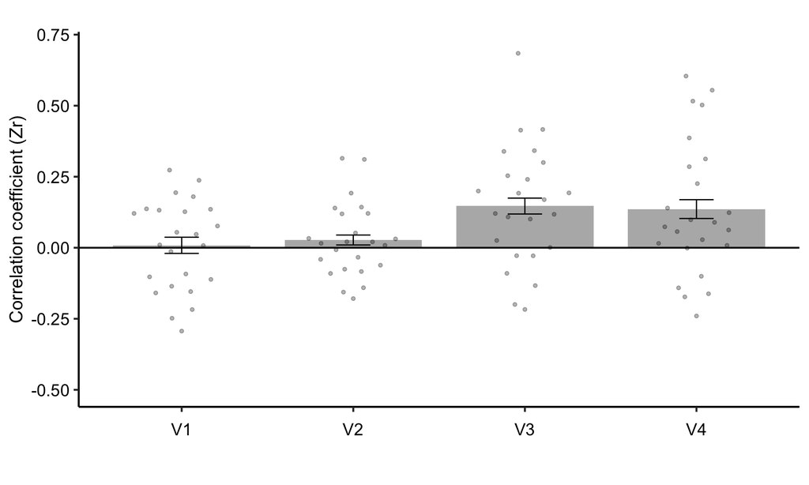

```r
# ggsave("fBGRED_main7_verNSM.jpg", plot = r5_RG_with_bgfc.1, width=10, height=6, unit='in', dpi=600)
s1_allL.tmp <- s1_allL %>% filter(hRoi == "PPA")
s1_allG.tmp <- s1_allG %>% filter(hRoi == "PPA")
s1_allG.tmp$Zr <- s1_allG.tmp$Zr.m
r5_RG_with_bgfc.1 <- ggplot(data=s1_allL.tmp, aes(x=vRoi, y=Zr, fill = vRoi)) + #, fill=vRoi
  # geom_violin(width = 0.5, trim=TRUE) +
  # ggbeeswarm::geom_quasirandom(color = "blue", size = 3, alpha = 0.2, width = 0.2) +
  stat_summary(fun = mean, geom = "bar", position="dodge", na.rm = TRUE, alpha = .9, width = 0.8,  size = 1.02, show.legend=F) +
  geom_hline(yintercept=0, linetype='solid', alpha =1, size=0.75) + #, color='black'
  # geom_jitter(data=s1_allL.tmp, aes(x=vRoi, y=Zr, color=vRoi),
  #             position=position_jitter(0.2), cex=2) +
  geom_quasirandom(data=s1_allL.tmp, aes(x=vRoi, y=Zr),
                   color = "black", fill = "#adadad",
                   alpha = 0.3, #position = "nudge",
                   width = 0.3,
                   size = 1.3,
                   position=position_jitter(0.05),
                   # position="jitter",
                   inherit.aes = TRUE,
                   show.legend = F) +

  # geom_dotplot(data=s1_allL.tmp, aes(x=vRoi, y=Zr, fill=vRoi),
  #              binaxis = "y", stackdir = "center", stackratio = 1.2,
  #              color = "black", alpha = 0.5, #position = "nudge",
  #              position=position_jitter(0.2),
  #              # position="jitter",
  #              inherit.aes = TRUE, binwidth = 0.02) +
  # geom_point(data=s1_allL.tmp, aes(x=vRoi, y=Zr, fill=vRoi), position = position_jitter(0.2),
  #           size=2, show.legend=F, color="gray90") +
  # geom_pointrange(data=s1_allG.tmp, aes(x = vRoi, y=Zr.m, ymin = lower.se, ymax = upper.se),
  #                 position = position_dodge(0.80), color = "darkred", size = 0.8, show.legend = FALSE) +
  geom_errorbar(data=s1_allG.tmp, aes(ymin=lower.se, ymax=upper.se), width=.2,
                position=position_dodge(.8), color = "black") +

  scale_x_discrete(labels=c("V1","V2","V3","V4")) +
  scale_fill_manual(values = c("#adadad", "#adadad","#adadad", "#adadad")) +
  # scale_fill_manual(values = c("#B1D4E0", "#2E8BC0","#0C2D48", "#145DA0")) +
  coord_cartesian(ylim = c(-0.5, 0.7), clip = "on") +
  labs(x = "", y = "Correlation coefficient (Zr)") +
  theme_bw(base_size = 18) +
  theme(axis.title = element_text(face = "plain", size = 16, color = "black"),
        axis.text = element_text(face = "plain", hjust = 0.5, size = 15, color = "black"),
        axis.line=element_line(),
        axis.title.y = element_text(face = "plain", size = 16, color = "black"),
        axis.title.x = element_text(face = "plain", size = 16, vjust = -2.5, color = "black"),
        axis.text.x = element_text(face = "plain", vjust = -1, size = 15, color = "black"),
        strip.text.x = element_text(face = "plain", size = 15, color = "black"),
        strip.background = element_blank(),
        panel.grid.major = element_blank(),
        panel.grid.minor = element_blank(),
        panel.border = element_blank(),
        panel.spacing=unit(1, "lines"),
        plot.margin = margin(1, 0.3, 1, 0.3, "cm"),
        legend.title = element_blank(),
        legend.position="top")

r5_RG_with_bgfc.1
```

```r
# ggsave("fBGRED_main8_verNSM.jpg", plot = r5_RG_with_bgfc.1, width=8, height=6, unit='in', dpi=600)
```

```r
s1.aov1.1 <- aov_ez(id="subj", dv="Zr", data = s1_allL , within = c("vRoi", "hRoi"),
                    anova_table = list(correction = "none"))
#summary(t4.2.aov4.2)
nice(s1.aov1.1, es="pes") %>% kable(digits=3)
```

| Effect | df | MSE | F | pes | p.value |
| --- | --- | --- | --- | --- | --- |
| vRoi | 3, 69 | 0.06 | 5.60 ** | .196 | .002 |
| hRoi | 2, 46 | 0.00 | 0.18 | .008 | .838 |
| vRoi:hRoi | 6, 138 | 0.00 | 0.73 | .031 | .624 |

```r
ph1 <- s1_allL %>%
  group_by(hRoi) %>%
  rstatix::pairwise_t_test(Zr ~ vRoi,
                           p.adjust.method="bonferroni",
                           paired=T, detailed=T) %>%
  dplyr::select(hRoi, group1, group2, estimate, conf.low, conf.high, df, statistic, p.adj, p.adj.signif)

ph2 <- s1_allL %>%
  group_by(hRoi) %>%
  rstatix::cohens_d(Zr ~ vRoi, paired=T, ci = F) %>%
  dplyr::select(hRoi, group1, group2, effsize, magnitude)

merge(ph1, ph2, by = c("hRoi",  "group1", "group2")) %>% kable(digits=3)
```

| hRoi | group1 | group2 | estimate | conf.low | conf.high | df | statistic | p.adj | p.adj.signif | effsize | magnitude |
| --- | --- | --- | --- | --- | --- | --- | --- | --- | --- | --- | --- |
| lPPA | v1 | v2 | 0.000 | -0.047 | 0.048 | 23 | 0.020 | 1.000 | ns | 0.004 | negligible |
| lPPA | v1 | v3 | -0.112 | -0.212 | -0.012 | 23 | -2.325 | 0.176 | ns | -0.475 | small |
| lPPA | v1 | v4 | -0.104 | -0.212 | 0.003 | 23 | -2.003 | 0.343 | ns | -0.409 | small |
| lPPA | v2 | v3 | -0.113 | -0.190 | -0.035 | 23 | -3.018 | 0.037 | * | -0.616 | moderate |
| lPPA | v2 | v4 | -0.105 | -0.186 | -0.023 | 23 | -2.663 | 0.083 | ns | -0.544 | moderate |
| lPPA | v3 | v4 | 0.008 | -0.073 | 0.089 | 23 | 0.205 | 1.000 | ns | 0.042 | negligible |
| PPA | v1 | v2 | -0.019 | -0.066 | 0.029 | 23 | -0.810 | 1.000 | ns | -0.165 | negligible |
| PPA | v1 | v3 | -0.138 | -0.238 | -0.038 | 23 | -2.852 | 0.054 | ns | -0.582 | moderate |
| PPA | v1 | v4 | -0.127 | -0.239 | -0.016 | 23 | -2.370 | 0.160 | ns | -0.484 | small |
| PPA | v2 | v3 | -0.119 | -0.198 | -0.040 | 23 | -3.128 | 0.028 | * | -0.639 | moderate |
| PPA | v2 | v4 | -0.109 | -0.199 | -0.018 | 23 | -2.482 | 0.125 | ns | -0.507 | moderate |
| PPA | v3 | v4 | 0.011 | -0.078 | 0.099 | 23 | 0.250 | 1.000 | ns | 0.051 | negligible |
| rPPA | v1 | v2 | -0.034 | -0.084 | 0.016 | 23 | -1.388 | 1.000 | ns | -0.283 | small |
| rPPA | v1 | v3 | -0.145 | -0.241 | -0.049 | 23 | -3.135 | 0.028 | * | -0.640 | moderate |
| rPPA | v1 | v4 | -0.129 | -0.241 | -0.016 | 23 | -2.362 | 0.162 | ns | -0.482 | small |
| rPPA | v2 | v3 | -0.112 | -0.191 | -0.032 | 23 | -2.905 | 0.048 | * | -0.593 | moderate |
| rPPA | v2 | v4 | -0.095 | -0.193 | 0.003 | 23 | -2.005 | 0.341 | ns | -0.409 | small |
| rPPA | v3 | v4 | 0.017 | -0.074 | 0.108 | 23 | 0.376 | 1.000 | ns | 0.077 | negligible |

각 관심 영역에서 voxel 별 difference score와 bgFC의 Zr이 0보다 유의하게 큰 지 확인하기 위해 단일 표본 t-검정을 수행하였다.

```r
p_h1 <- s1_allL %>%
  group_by(hRoi, vRoi) %>%
  rstatix::t_test(Zr ~ 1, mu = 0, detailed= T, alternative = "two.sided") %>%
  dplyr::select(hRoi, vRoi, estimate, conf.low, conf.high, df, statistic, p)


p_h2 <- s1_allL %>%
  group_by(hRoi, vRoi) %>%
  rstatix::cohens_d(Zr ~ 1, mu = 0, ci = F) %>%
  dplyr::select(hRoi, vRoi, effsize, magnitude)

merge(p_h1, p_h2, by = c("hRoi", "vRoi")) %>% kable(digits=3)
```

| hRoi | vRoi | estimate | conf.low | conf.high | df | statistic | p | effsize | magnitude |
| --- | --- | --- | --- | --- | --- | --- | --- | --- | --- |
| lPPA | v1 | 0.021 | -0.045 | 0.088 | 23 | 0.668 | 0.511 | 0.136 | negligible |
| lPPA | v2 | 0.021 | -0.028 | 0.070 | 23 | 0.881 | 0.387 | 0.180 | negligible |
| lPPA | v3 | 0.134 | 0.044 | 0.224 | 23 | 3.068 | 0.005 | 0.626 | moderate |
| lPPA | v4 | 0.126 | 0.033 | 0.218 | 23 | 2.804 | 0.010 | 0.572 | moderate |
| PPA | v1 | 0.009 | -0.059 | 0.076 | 23 | 0.262 | 0.796 | 0.054 | negligible |
| PPA | v2 | 0.027 | -0.028 | 0.082 | 23 | 1.021 | 0.318 | 0.208 | small |
| PPA | v3 | 0.147 | 0.057 | 0.237 | 23 | 3.367 | 0.003 | 0.687 | moderate |
| PPA | v4 | 0.136 | 0.034 | 0.238 | 23 | 2.765 | 0.011 | 0.564 | moderate |
| rPPA | v1 | -0.002 | -0.072 | 0.067 | 23 | -0.068 | 0.946 | -0.014 | negligible |
| rPPA | v2 | 0.031 | -0.029 | 0.092 | 23 | 1.073 | 0.294 | 0.219 | small |
| rPPA | v3 | 0.143 | 0.057 | 0.229 | 23 | 3.436 | 0.002 | 0.701 | moderate |
| rPPA | v4 | 0.126 | 0.024 | 0.228 | 23 | 2.560 | 0.018 | 0.523 | moderate |